# Explaining the latent trend of tranmission

Andrew Tredennick

24 January, 2022

## Goal of manuscript

*Goal* Demonstrate why a semi-parametric model is necessary to model ongoing pandemics where transmission rates can change rapidly in response to human actions that difficult or impossible to measure.

*How?* Show that the non-parametric portion of the model “takes over” as the driver of temporal variation after the first few weeks of the pandemic. This can be done by a segmented analysis of variance, with the segment defined by the date at which most mandates began to expire in each state; I used May 01, 2020 here for demonstration.

## Initial analyses

NOTE: We need to use the 2020-12-31 model fit. This will require a little bit of post-processing to get those archived results in shape (to have the same structure as the “current” directory files).

Here I am using the most recent fit.

First, we want to know how much of the variation in Reff over time is due to the mobility covariate versus the latent trend. This is over all time. The eventual goal is to show over moving window or in segmented times (see below).

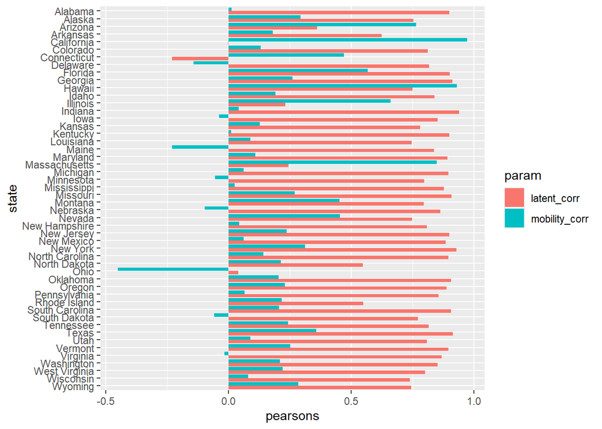

Looks like latent correlation is highest for almost all states, so, we verify that it is important.

Let’s look at all the time series, including the mandates.

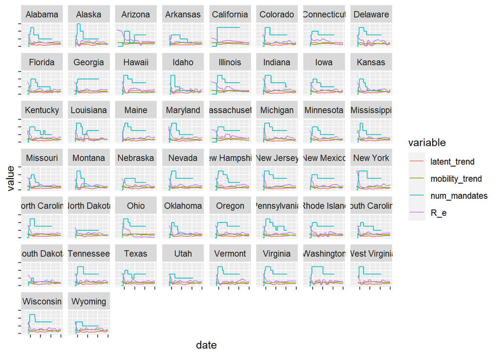

## Analysis of Variance

Here we show that easy-to-measure metrics such as human mobility are useful predictors early in the pandemic when mandates were in place. After about May 01, 2020, many mandates expired and human mobility became less useful as a predictor. The latent trend capture nearly all the variance in R_e after mandates expired, except in some interesting cases like California. NOTE: THIS IS FROM A POTENTIALLY BAD FIT FOR CALIFORNIA AND ILLINOIS. WE NEED TO FIND THE BEST FIT CLOSEST TO DEC 31, 2020.

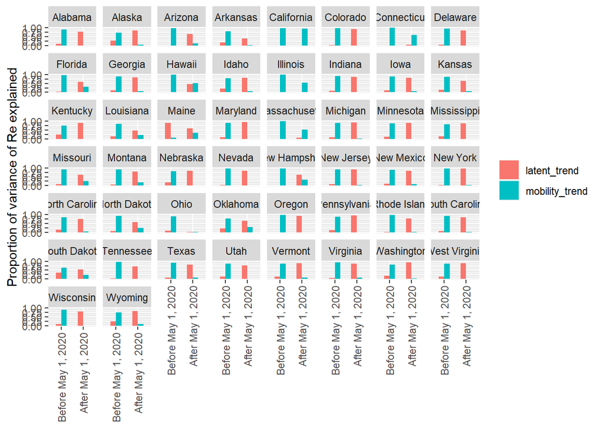